# Two sample t-test

2025-05-28

Let’s compare the means of two samples using independent t-test (and paired t-test as extra exercises)

- Replace _ to complete expressions and return the correct answer
- Restart R to remove previous results using: Ctrl/Cmd + shift + F10
- Remember - try to use Google to help you answer questions

## Import the packages

Import the `tidyverse` for `dplyr` and `ggplot2` packages

```r
library(tidyverse)
```

## Two-sample t-test

`River_pH.csv` contains pH measurements between two rivers. A researcher is interested if the mean pH is different between the two rivers.

### Import data

Import `river_ph.csv` from the `data/` folder

> Note the issues about running code in the document and trying to knit when the file is in the `student-material/` folder. I moved the `.Rmd` file to the `r-for-scientific-research` folder

```r
river_ph <-
  readr::read_csv("data/river_ph.csv")
```

### Examine the dataset

- How many columns are there?
- How many values of River_name are there?
- How many samples in each group?

```r
# 2 columns
# 20 rows
# 10 smaples for each river
glimpse(river_ph)
```

```
## Rows: 20
## Columns: 2
## $ River_name <chr> "Fair", "Fair", "Fair", "Fair", "Fair", "Fair", "Fair", "Fa…
## $ pH         <dbl> 8.968143, 9.119740, 9.413058, 8.665746, 9.937042, 8.280083,…
```

```r
river_ph |>
  count(River_name)
```

```
## # A tibble: 2 × 2
##   River_name     n
##   <chr>      <int>
## 1 Elstone       10
## 2 Fair          10
```

### Visualise data

Visualise the data using a boxplot. Does there appear to be a difference in pH?

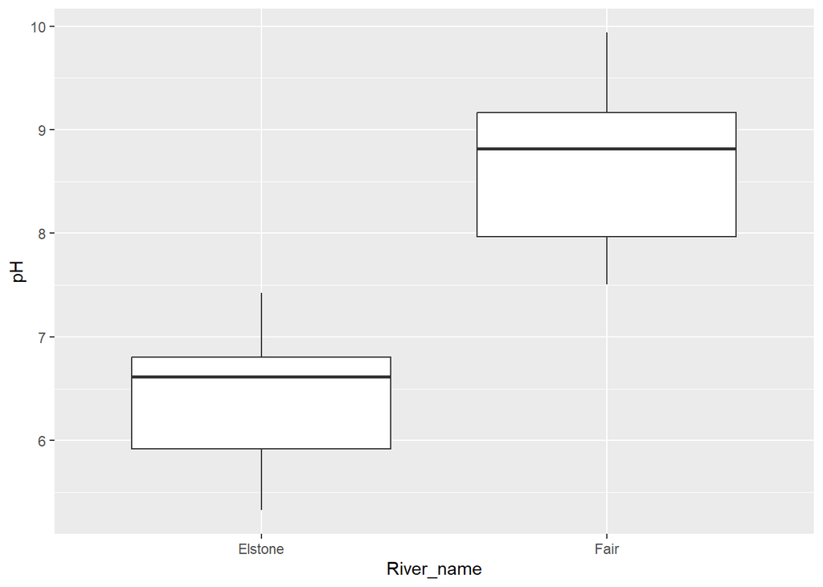

```r
river_plot <-
  river_ph %>%
  ggplot(aes(x=River_name, y = pH)) +
  geom_boxplot()

river_plot
```

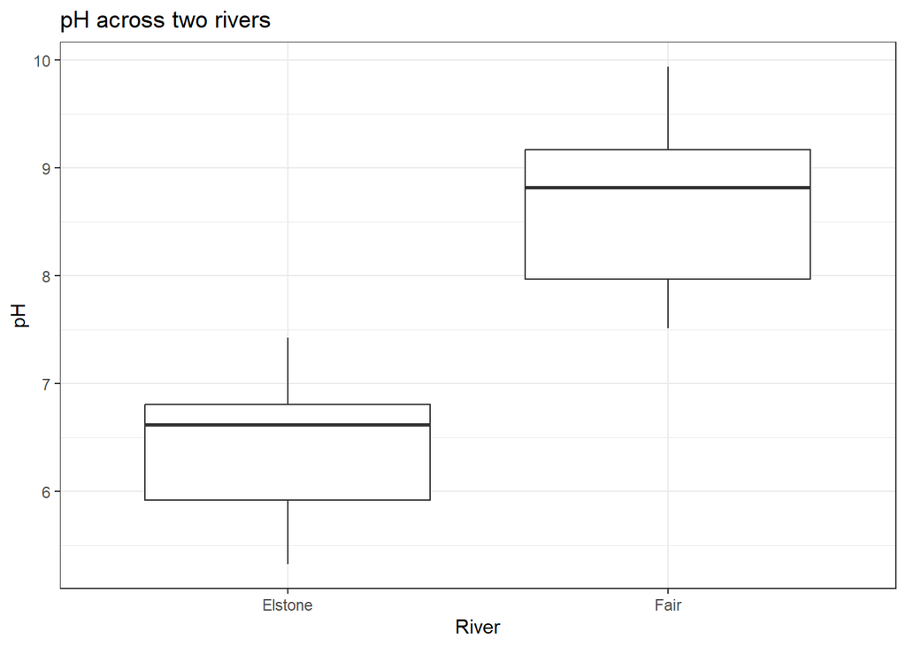

```r
# river_ph %>%
#   _
river_plot +
  labs(x = "River",
       y = "pH",
       title = "pH across two rivers") +
  theme_bw()
```

```r
ggsave(filename = "outputs/river_ph.png",
       width = 120, height = 120, units = "mm")
```

### Summarise

Obtain a data summary including - the number of samples - mean - standard deviation (sd) - standard error ( sd / sqrt(n) )

```r
river_ph_data_summary <-
  river_ph %>%
  group_by(River_name) %>%
  summarise(
    n_samples = n(),
    mean_pH = mean(pH, na.rm = T),
    sd_pH = sd(pH, na.rm = T),
    se_pH = sd_pH / sqrt(n_samples)
  )

river_ph_data_summary
```

```
## # A tibble: 2 × 5
##   River_name n_samples mean_pH sd_pH se_pH
##   <chr>          <int>   <dbl> <dbl> <dbl>
## 1 Elstone           10    6.41 0.627 0.198
## 2 Fair              10    8.66 0.806 0.255
```

### Conduct t-test

What is the null hypothesis here?

```
There is no difference in the mean pH between the two rivers.
```

Conduct a t.test of pH between rivers.

- Assume equal variances for traditional t-test (var.equal = T)
- Remember to use a formula y ~ x

```r
t.test(pH ~ River_name, data = river_ph, var.equal = T)
```

```
##
##  Two Sample t-test
##
## data:  pH by River_name
## t = -6.9788, df = 18, p-value = 1.618e-06
## alternative hypothesis: true difference in means between group Elstone and group Fair is not equal to 0
## 95 percent confidence interval:
##  -2.931168 -1.574706
## sample estimates:
## mean in group Elstone    mean in group Fair
##              6.408560              8.661497
```

```
There was a significant difference between mean pH of the two rivers (t = -7.0, df = 18, p = < 0.05). The pH was greater in the river Fair (8.7) compared with Elstone (6.4)
```

## Additional exercises - Paired t-test

`madrid-weather-monthly-2010-2020.csv` contains daily temperature, humidity and precipitation every two years from 2010 to 2020.

A researcher wants to know if there is a difference in monthly temperature, on average, between the year 2010 and the year 2020. We will pair the months from each year and conduct a paired t-test.

```r
### Import data
madrid_weather <-
  readr::read_csv("data/madrid-weather-monthly-2010-2020.csv")
### Prepare data

# - Filter the data for the years 2010 and 2020
# - Summarise the daily data by year and month to obtain mean monthly Temperature_C

madrid_weather_monthly_2010_2020 <-
  madrid_weather %>%
  filter(year %in% c(2010, 2020)) %>%
  group_by(year, month) %>%
  summarise(
    Temperature_C = mean(Temperature_C),
    .groups = 'drop'
  )

madrid_weather_monthly_2010_2020
```

```
## # A tibble: 24 × 3
##     year month Temperature_C
##    <dbl> <dbl>         <dbl>
##  1  2010     1          4.87
##  2  2010     2          5.86
##  3  2010     3          8.77
##  4  2010     4         14.9
##  5  2010     5         17.6
##  6  2010     6         23.4
##  7  2010     7         31.4
##  8  2010     8         29.5
##  9  2010     9         23.1
## 10  2010    10         15.4
## # ℹ 14 more rows
```

```r
# Next you need to pivot the data so there are 2 columns of monthly data from 2010 and 2020

madrid_weather_monthly_2010_2020_wide <-
  madrid_weather_monthly_2010_2020 %>%
  pivot_wider(names_from = year,
              values_from = Temperature_C,
              names_prefix = 'year_')

madrid_weather_monthly_2010_2020_wide
```

```
## # A tibble: 12 × 3
##    month year_2010 year_2020
##    <dbl>     <dbl>     <dbl>
##  1     1      4.87      8.58
##  2     2      5.86     12.9
##  3     3      8.77     12.3
##  4     4     14.9      14.9
##  5     5     17.6      21.5
##  6     6     23.4      24.3
##  7     7     31.4      31.1
##  8     8     29.5      28.4
##  9     9     23.1      23.3
## 10    10     15.4      16.5
## 11    11      8.97     13.5
## 12    12      6.19      7.90
```

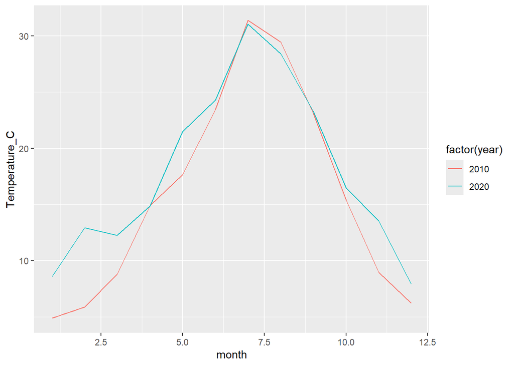

```r
### Plot the data

# There a different ways to do this. To save time, I've provided a two

#### Using a line graph

# - Plot monthly temperature as two coloured lines from each year
# - There should only be 2 values in the legend

madrid_weather_monthly_2010_2020 %>%
  ggplot(aes(x = month, y = Temperature_C, color = factor(year))) +
  geom_line()
```

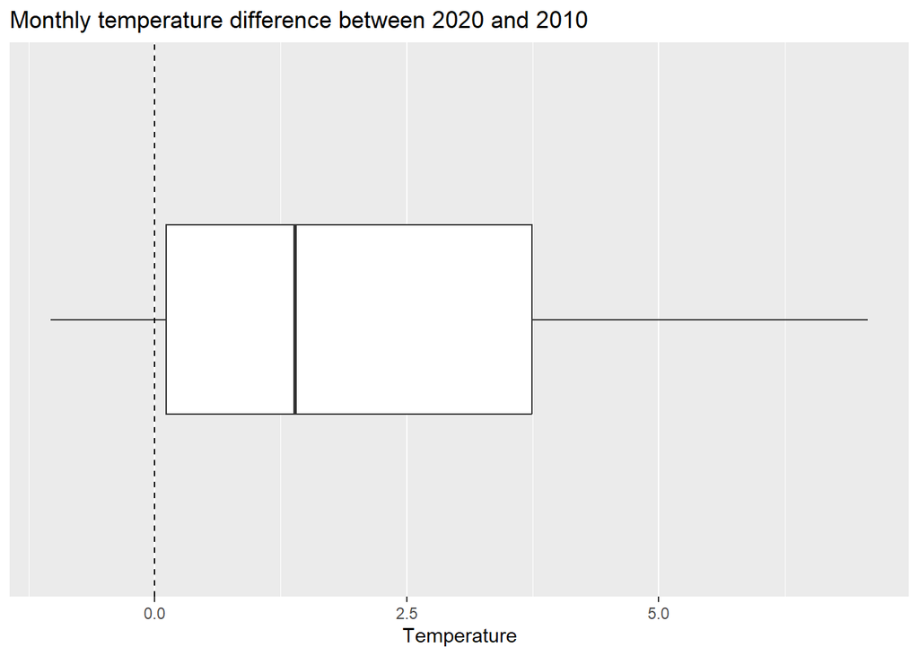

```r
#### Boxplot of differences

# - Calculate the difference between 2020 and 2010
# - Then use a boxplot to plot the calculated difference

madrid_weather_monthly_2010_2020_wide %>%
  mutate(temp_difference = year_2020 - year_2010) %>%
  ggplot(aes(x = temp_difference)) +
  geom_boxplot() +
  scale_y_continuous(limits = c(-1,1),
                     breaks = NULL) +
  geom_vline(xintercept = 0, linetype = 'dashed') +
  labs(title = 'Monthly temperature difference between 2020 and 2010',
       x = 'Temperature')
```

```r
# Export the plot if you wish


### Conduct a paired t-test

# What is the null hypothesis here?
# The mean difference between paired values includes 0 in the confidence interval

# - Remember to provide the arguments x and y the columns of the data, and to
# - use the argument paired = TRUE


t.test(
  x = madrid_weather_monthly_2010_2020_wide$year_2020,
  y = madrid_weather_monthly_2010_2020_wide$year_2010,
  paired = TRUE
)
```

```
##
##  Paired t-test
##
## data:  madrid_weather_monthly_2010_2020_wide$year_2020 and madrid_weather_monthly_2010_2020_wide$year_2010
## t = 2.9783, df = 11, p-value = 0.01256
## alternative hypothesis: true mean difference is not equal to 0
## 95 percent confidence interval:
##  0.545724 3.636305
## sample estimates:
## mean difference
##        2.091014
```

```r
# Write a short summary sentence
# The mean difference in monthly temperature between 2020 and 2010 was 2.1 (95% CI 0.54 to 3.6). This difference was significantly different from 0 (t-paired = 2.98, df = 11, P = 0.01)
```

## Conclusion

We examined

- independent t-test
- paired t-test
- reviewed some data manipulation
- reviewed some data visualisation